# Interrupted Time Series Analysis

KJ

2023-11-12

### Interrupted Time Series Analysis (ITSA)

## Introduction

ITSA is a statistical method for analyzing longitudinal data that are susceptible to external events or interventions. ITSA allows us to estimate the effect of an intervention in the real world and evaluate whether it has been effective. ITSA can be used to evaluate interventions in various fields, such as healthcare, education, and policy.

Watch the video on Interrupted Time Series Analysis: https://www.youtube.com/watch?v=CYiDyLT6Wf4

## Install and Load Necessary Packages

First, install and load the necessary packages. You’ll need lme4 for linear mixed-effects models, and lmerTest for getting p-values.

```r
#install.packages("lme4")
#install.packages("lmerTest")
library(lme4)
library(lmerTest)
```

## Load the data and Choose an Outcome Variable

Load the data, and select an outcome variable for the analysis. For example, if you want to analyze the effect on ‘fear_nrc’, you would use this as your dependent variable.

```r
library(readr)
combined_emotion<-read_csv("D:/Dropbox/aa_students/yuanyuan/combined_emotion.csv",show_col_types = FALSE)
combined_emotion$date <- as.Date(combined_emotion$date)

emotion_cols <- c("disgust_nrc", "fear_nrc", "trust_nrc", "anticipation_nrc",
                 "surprise_nrc", "anger_nrc", "joy_nrc", "sadness_nrc",
                 "POSEMO_liwc", "SAD_liwc", "NEGEMO_liwc", "ANGER_liwc", "ANX_liwc")
```

# Fill NA Values with 0

```r
combined_emotion[emotion_cols] <- lapply(combined_emotion[emotion_cols], function(x) replace(x, is.na(x), 0))
```

# Calculate Mean, Max, and SD

```r
library(dplyr)
stats <- combined_emotion %>%
  select(all_of(emotion_cols)) %>%
  summarise(across(everything(), list(mean = mean, max = max, sd = sd)))

print(stats)
```

```
## # A tibble: 1 × 39
##   disgust_nrc_…¹ disgu…² disgu…³ fear_…⁴ fear_…⁵ fear_…⁶ trust…⁷ trust…⁸ trust…⁹
##            <dbl>   <dbl>   <dbl>   <dbl>   <dbl>   <dbl>   <dbl>   <dbl>   <dbl>
## 1         0.0411    1.55  0.0223  0.0436    1.41  0.0227  0.0348    1.34  0.0205
## # … with 30 more variables: anticipation_nrc_mean <dbl>,
## #   anticipation_nrc_max <dbl>, anticipation_nrc_sd <dbl>,
## #   surprise_nrc_mean <dbl>, surprise_nrc_max <dbl>, surprise_nrc_sd <dbl>,
## #   anger_nrc_mean <dbl>, anger_nrc_max <dbl>, anger_nrc_sd <dbl>,
## #   joy_nrc_mean <dbl>, joy_nrc_max <dbl>, joy_nrc_sd <dbl>,
## #   sadness_nrc_mean <dbl>, sadness_nrc_max <dbl>, sadness_nrc_sd <dbl>,
## #   POSEMO_liwc_mean <dbl>, POSEMO_liwc_max <dbl>, POSEMO_liwc_sd <dbl>, …
## # ℹ Use `colnames()` to see all variable names
```

# Create Histograms for Each Column

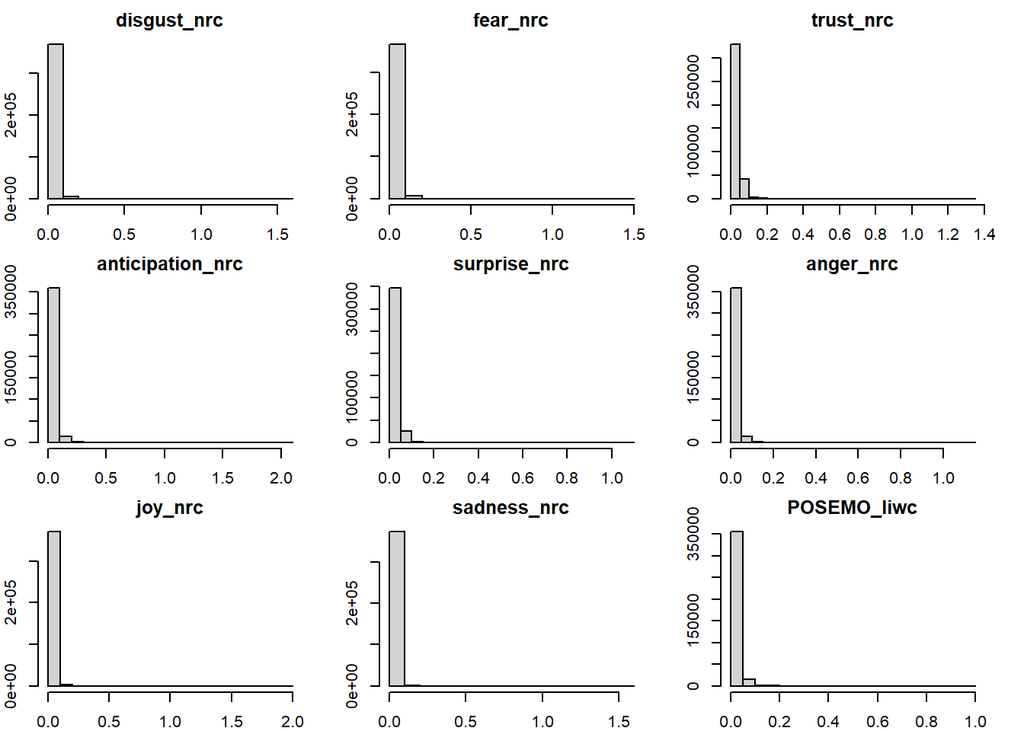

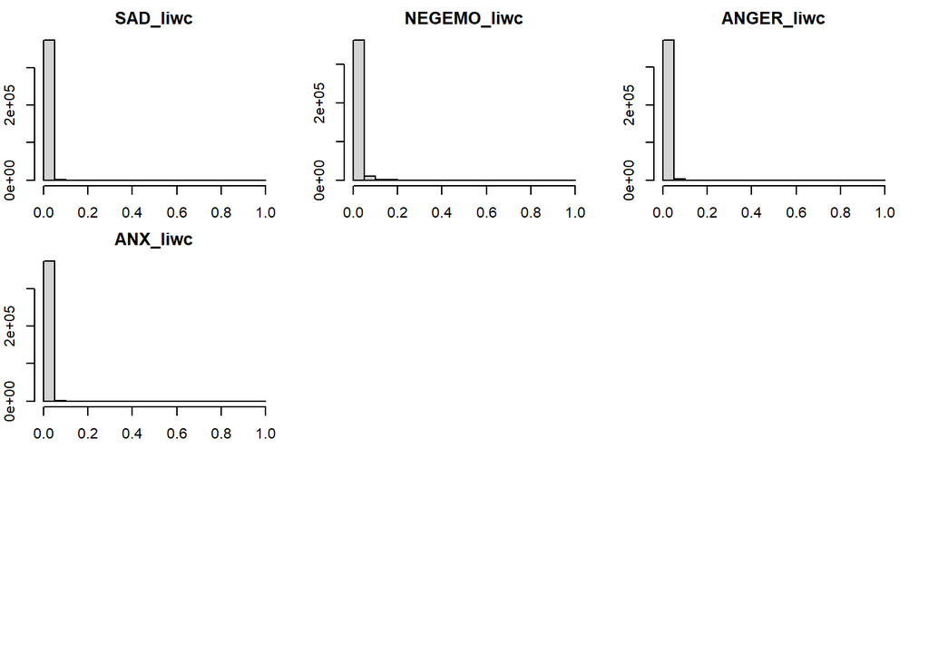

```r
# Open a new window with specified size
#windows(width=10, height=8)  # On mac, use X11()

#par(mfrow = c(4, 4)) # Adjust the grid size based on the number of variables

# Set smaller margins
par(mar=c(2, 2, 2, 2))

par(mfrow = c(3, 3)) # Adjust based on your needs

for (col in emotion_cols) {
  hist(combined_emotion[[col]], main = col, xlab = col)
}
```

## Bootstrapping

You have already calculated daily means.. but if you had raw files with individual-level observations, here is how you would prepare the data.

Bootstrapping is a powerful statistical technique used for estimating the distribution of a statistic (like a mean or standard deviation) by resampling with replacement from the original data. It allows for the assessment of the variability or uncertainty of a statistical estimate when the true population distribution is unknown or the sample size is small. By repeatedly resampling the data and recalculating the statistic for each sample, bootstrapping builds an empirical distribution of the statistic. This empirical distribution can then be used to estimate confidence intervals, standard errors, and significance tests, providing a non-parametric alternative to traditional parametric methods. Bootstrapping is particularly useful because it is straightforward to implement and does not rely on assumptions about the data’s underlying distribution, making it versatile for a wide range of applications.

# Step 1 Load necessary libraries

```r
library(dplyr)
library(tidyr)
library(purrr)
```

# Step 2: Define the bootstrapping function

Create a function that will perform the bootstrap sampling for each day.

```r
bootstrap_day <- function(data, n = 100) {
  sample_n(data, size = n, replace = TRUE)
}

# Function to sample with replacement
sample_with_replacement <- function(data, n = 100) {
  if (nrow(data) >= n) {
    sample_n(data, size = n, replace = TRUE)
  } else {
    sample_n(data, size = n, replace = TRUE, weight = rep(1/nrow(data), nrow(data)))
  }
}
```

# Step 3: Split Data by Day and Sample with Replacement

```r
set.seed(123) # For reproducibility


# Apply the sampling function to each group
## warning: this creates a HUGE FILE
sampled_data <- combined_emotion %>%
  group_by(date, county) %>%
  sample_with_replacement()

# View the resulting dataframe
print(sampled_data)
```

```
## # A tibble: 37,394,500 × 17
## # Groups:   date, county [373,945]
##     ...1 group_id      date       county disgu…¹ fear_…² trust…³ antic…⁴ surpr…⁵
##    <dbl> <chr>         <date>     <chr>    <dbl>   <dbl>   <dbl>   <dbl>   <dbl>
##  1     1 2020-09-01_0… 2020-09-01 01001   0.0415  0.0496  0.0419  0.0573  0.0395
##  2     1 2020-09-01_0… 2020-09-01 01001   0.0415  0.0496  0.0419  0.0573  0.0395
##  3     1 2020-09-01_0… 2020-09-01 01001   0.0415  0.0496  0.0419  0.0573  0.0395
##  4     1 2020-09-01_0… 2020-09-01 01001   0.0415  0.0496  0.0419  0.0573  0.0395
##  5     1 2020-09-01_0… 2020-09-01 01001   0.0415  0.0496  0.0419  0.0573  0.0395
##  6     1 2020-09-01_0… 2020-09-01 01001   0.0415  0.0496  0.0419  0.0573  0.0395
##  7     1 2020-09-01_0… 2020-09-01 01001   0.0415  0.0496  0.0419  0.0573  0.0395
##  8     1 2020-09-01_0… 2020-09-01 01001   0.0415  0.0496  0.0419  0.0573  0.0395
##  9     1 2020-09-01_0… 2020-09-01 01001   0.0415  0.0496  0.0419  0.0573  0.0395
## 10     1 2020-09-01_0… 2020-09-01 01001   0.0415  0.0496  0.0419  0.0573  0.0395
## # … with 37,394,490 more rows, 8 more variables: anger_nrc <dbl>,
## #   joy_nrc <dbl>, sadness_nrc <dbl>, POSEMO_liwc <dbl>, SAD_liwc <dbl>,
## #   NEGEMO_liwc <dbl>, ANGER_liwc <dbl>, ANX_liwc <dbl>, and abbreviated
## #   variable names ¹disgust_nrc, ²fear_nrc, ³trust_nrc, ⁴anticipation_nrc,
## #   ⁵surprise_nrc
## # ℹ Use `print(n = ...)` to see more rows, and `colnames()` to see all variable names
```

# Step 4: Aggregate to day level

```r
library(data.table)
setDT(sampled_data)  # Convert to data.table
emotion_cols <- c("disgust_nrc", "fear_nrc", "trust_nrc", "anticipation_nrc",
                  "surprise_nrc", "anger_nrc", "joy_nrc", "sadness_nrc",
                  "POSEMO_liwc", "SAD_liwc", "NEGEMO_liwc", "ANGER_liwc", "ANX_liwc")


day_level_aggregated <- sampled_data[, lapply(.SD, mean, na.rm = TRUE), by = .(date, county), .SDcols = emotion_cols]

#day_level_aggregated <- sampled_data %>%
#  group_by(date,county) %>%
#  summarise(across(all_of(emotion_cols), mean, na.rm = TRUE))
```

## Prepare Your Data

Ensure your data is in the correct format. The date column should be a Date or a numeric time variable. If necessary, create a time variable representing the time sequence (e.g., weeks, months) and a binary intervention variable indicating pre- and post-intervention periods.

```r
day_level_aggregated$time <- as.numeric(day_level_aggregated$date) # Convert date to numeric time
day_level_aggregated$intervention1 <- ifelse(day_level_aggregated$date >= as.Date("2020-12-14"), 1, 0) # Replace "YYYY-MM-DD" with intervention date
day_level_aggregated$intervention2 <- ifelse(day_level_aggregated$date >= as.Date("2020-11-09"), 1, 0) # Replace "YYYY-MM-DD" with intervention date
```

## Model Specification

Specify the mixed-effects model using lmer from the lme4 package. The basic model includes fixed effects for time, intervention, and an interaction term between time and intervention. Random effects are included for the ‘county’ to account for clustering.

```r
library(lmerTest)
model <- lmer(fear_nrc ~ time + intervention1 + time:intervention1 + (1 | county), data = day_level_aggregated)
```

The linear mixed-effects model was fit using the `lmer` function to analyze the impact of an intervention over time on the `fear_nrc` response variable, accounting for the random effects due to different ‘counties’.

This formula indicates that fear_nrc is predicted as a function of time, intervention1, and their interaction. The (1 | county) term suggests that random intercepts for each county are included.

# Model checking

Check the model for assumptions like normality of residuals and homoscedasticity. You can use diagnostic plots for this.

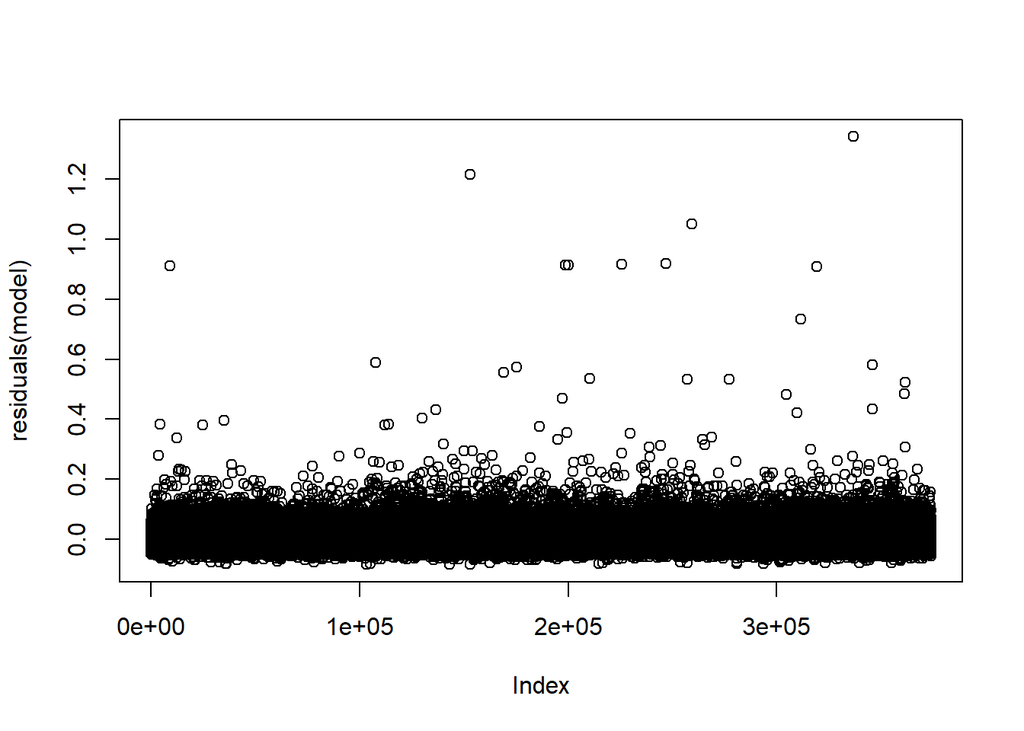

```r
plot(residuals(model))
```

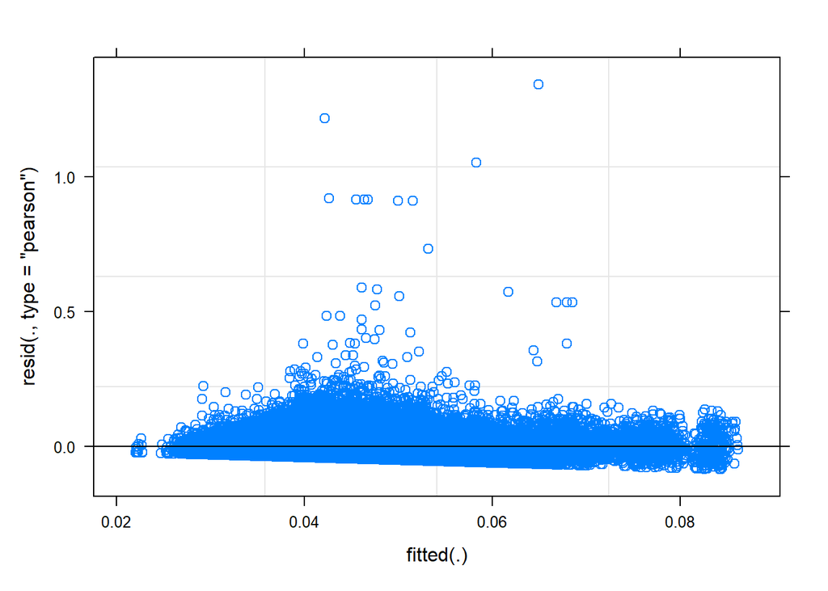

```r
plot(model)
```